# Project 2

The Impact of Coffee Consumption on sleep Quality and Duration

Tim Gutberlet

University of Sydney | 21 September 2022

# 1 Executive Summary

# 2 Full Report

## 2.1 Initial Data Analysis (IDA)

### 2.1.1 Source of the Data

The Data came from a survey called Coffee Research Study created in a google docs survey.  
[The link to our survey](https://docs.google.com/forms/d/e/1FAIpQLSdquRFlpcG9CVZWPfwit-VDEXhdcZutKy5YTDJrwvjw1HRTDw/viewform.)  
We exported the results into the csv-File “CoffeeStudy.csv”.

```r
#Get Tidyverse for the ggplot Analysis
library(tidyverse)
# Read in the survey data
survey = read.csv("CoffeeStudy.csv")
```

### 2.1.2 Structure of the Data

There are 49 rows and 12 variables as columns.

```r
## Size of data
dim(survey)
```

```
## [1] 49 12
```

Important variables for our Dataset are in the following table including discussion for reclassification:

| variable | Type | Reclassification needed |
| --- | --- | --- |
| How.many.hours.do.you.sleep.per.night.on.average. | number | No - hours can be float or int |
| How.would.you.consider.your.sleep.quality. | integer | No - sleep quality is an int from 0-10 |
| On.Average..How.many.Coffees.do.you.drink.a.week. | integer | No, only ints were allowed in the survey |

```r
## classification of data
str(survey)
```

```
## 'data.frame':    49 obs. of  12 variables:
##  $ Timestamp                                                                                : chr  "9/1/2022 13:24:50" "9/1/2022 13:31:33" "9/1/2022 13:39:58" "9/1/2022 13:42:49" ...
##  $ Are.you.a.University.Student.                                                            : chr  "Yes" "Yes" "Yes" "Yes" ...
##  $ How.many.years.have.you.already.been.at.University.                                      : num  5 1 1 1 2 1 2 1 2 1 ...
##  $ How.old.are.you                                                                          : int  5 18 21 19 19 20 22 21 20 18 ...
##  $ How.many.hours.do.you.sleep.per.night.on.average.                                        : num  5 7 8 7 7 8 7 6 7 6 ...
##  $ How.would.you.consider.your.sleep.quality.                                               : int  4 5 5 8 7 6 7 4 5 6 ...
##  $ Would.you.consider.yourself.an.active.coffee.drinker...Drink.Coffee.at.least.once.a.Week.: chr  "No" "Yes" "No" "Yes" ...
##  $ What.sort.of.Coffee.do.you.drink.at.least.once.a.Week.                                   : chr  "" "Cappuccino" "" "Latte" ...
##  $ On.Average..How.many.Coffees.do.you.drink.a.week.                                        : int  NA 5 NA 2 NA 5 7 NA 1 4 ...
##  $ How.many.years.have.you.drank.coffee.at.least.once.a.week.                               : int  NA 5 NA 1 NA 4 5 NA 2 3 ...
##  $ Where.do.you.usually.get.your.coffee.from                                                : chr  "" "Starbucks" "" "Homemade coffee" ...
##  $ On.What.times.of.the.day.do.you.usually.drink.your.coffee.                               : chr  "" "10:00 - 11:59" "" "8:00 - 9:59" ...
```

### 2.1.3 Limitations of the Data

Limitations are that we only have about 50 data rows (even less when only considering active coffee drinkers - see Graph below), which is a low amount of data for conclusions. Moreover the values for coffee consumption and sleep quality and duration are only estimations by the survey takers and could differ in reality.

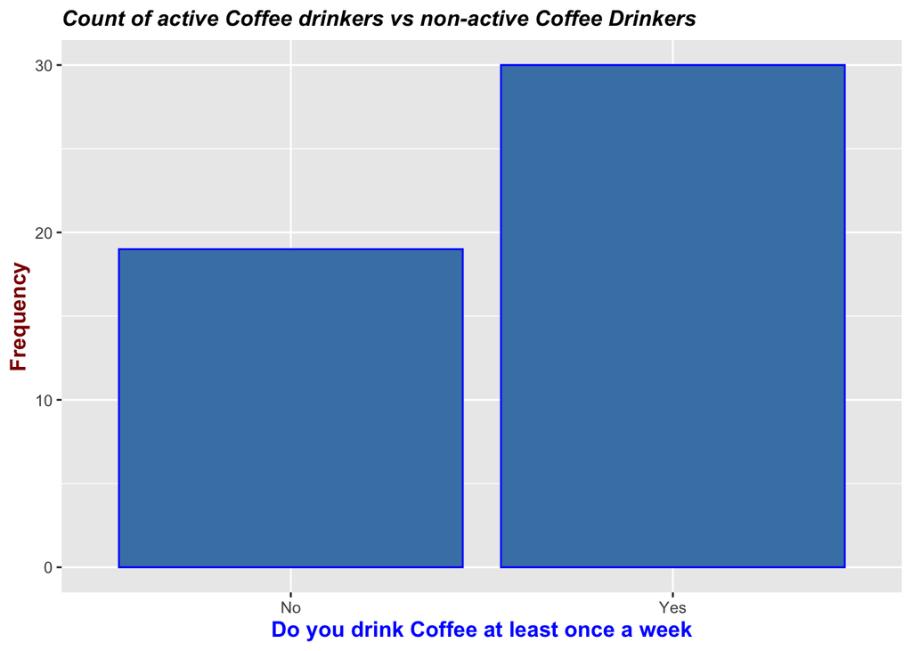

```r
ggplot(survey, aes(x = Would.you.consider.yourself.an.active.coffee.drinker...Drink.Coffee.at.least.once.a.Week.)) +
  geom_bar(color="blue", fill="steelblue") +
  xlab("Do you drink Coffee at least once a week") +
  ylab("Frequency") +
  ggtitle("Count of active Coffee drinkers vs non-active Coffee Drinkers") + theme(
plot.title = element_text(color="black", size=12, face="bold.italic" ),
axis.title.x = element_text(color="blue", size=12, face="bold"),
axis.title.y = element_text(color="darkred", size=12, face="bold")
)
```

### 2.1.4 Assumptions

We assume, that regular coffee consumption seen by the average coffee consumption per week has a negative effect on the sleep quality and duration.

### 2.1.5 Data Cleaning

It was important to change the titles of every columns, so that they are easier to read and to work with.

```r
# Rename column where names is "Sepal.Length"
names(survey)[names(survey) == "Are.you.a.University.Student."] <- "isStudent"
names(survey)[names(survey) == "How.many.years.have.you.already.been.at.University."] <- "universityYears"
names(survey)[names(survey) == "How.old.are.you"] <- "age"
names(survey)[names(survey) == "How.many.hours.do.you.sleep.per.night.on.average."] <- "sleepHours"
names(survey)[names(survey) == "How.would.you.consider.your.sleep.quality."] <- "sleepQuality"
names(survey)[names(survey) == "Would.you.consider.yourself.an.active.coffee.drinker...Drink.Coffee.at.least.once.a.Week."] <- "activeCoffeeDrinker"
names(survey)[names(survey) == "What.sort.of.Coffee.do.you.drink.at.least.once.a.Week."] <- "coffeeSort"
names(survey)[names(survey) == "On.Average..How.many.Coffees.do.you.drink.a.week."] <- "coffeeAverage"
names(survey)[names(survey) == "How.many.years.have.you.drank.coffee.at.least.once.a.week."] <- "yearsCoffee"
names(survey)[names(survey) == "Where.do.you.usually.get.your.coffee.from"] <- "coffeeSource"
names(survey)[names(survey) == "On.What.times.of.the.day.do.you.usually.drink.your.coffee."] <- "coffeTimes"


#str(survey)
```

Moreover we had to clean the dataset of all students that do not consume coffee regularly. This was done because for our research question we only need the data of students consuming coffee.

```r
#Drop all empty value rows out of the table and reassign it to the survey table
survey <- na.omit(survey)
```

## 2.2 Research Theme

We want to research what effect coffee consumption has on the sleep of University students. We want to find out if there is a negative (or maybe also positive) impact of coffee on sleep quality and duration. Consequently are two integrated research questions are:

### 2.2.1 Research Question 1

Firstly we want to research the relation of coffee consumption to the amount of sleep an individual gets.

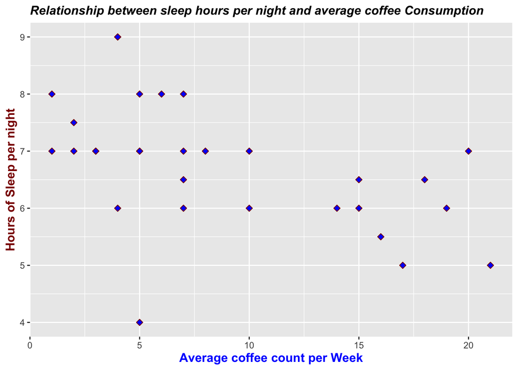

```r
ggplot(survey, aes(x = coffeeAverage, y = sleepHours)) +
  geom_point(shape=23, fill="blue", color="darkred", size=2) +
  xlab("Average coffee count per Week") +
  ylab("Hours of Sleep per night") +
  ggtitle("Relationship between sleep hours per night and average coffee Consumption") + theme(
plot.title = element_text(color="black", size=12, face="bold.italic" ),
axis.title.x = element_text(color="blue", size=12, face="bold"),
axis.title.y = element_text(color="darkred", size=12, face="bold")
)
```

```r
### Fitting the model
#Fit a model for Count of Coffee per Week to sleephours
fit <- lm(coffeeAverage~ sleepHours, data = survey)
fit # print
```

```
##
## Call:
## lm(formula = coffeeAverage ~ sleepHours, data = survey)
##
## Coefficients:
## (Intercept)   sleepHours
##      27.767       -2.825
```

```r
summary(fit)
```

```
##
## Call:
## lm(formula = coffeeAverage ~ sleepHours, data = survey)
##
## Residuals:
##      Min       1Q   Median       3Q      Max
## -11.4680  -4.0814  -0.0814   3.3129  12.0062
##
## Coefficients:
##             Estimate Std. Error t value Pr(>|t|)
## (Intercept)  27.7670     6.1668   4.503 0.000108 ***
## sleepHours   -2.8247     0.9017  -3.133 0.004034 **
## ---
## Signif. codes:  0 '***' 0.001 '**' 0.01 '*' 0.05 '.' 0.1 ' ' 1
##
## Residual standard error: 5.438 on 28 degrees of freedom
## Multiple R-squared:  0.2595, Adjusted R-squared:  0.2331
## F-statistic: 9.814 on 1 and 28 DF,  p-value: 0.004034
```

Firstly we look if there is a correlation, and it is a light correlation with -0.5094495.

```r
### Correlation
cor(survey$coffeeAverage,survey$sleepHours) #
```

```
## [1] -0.5094495
```

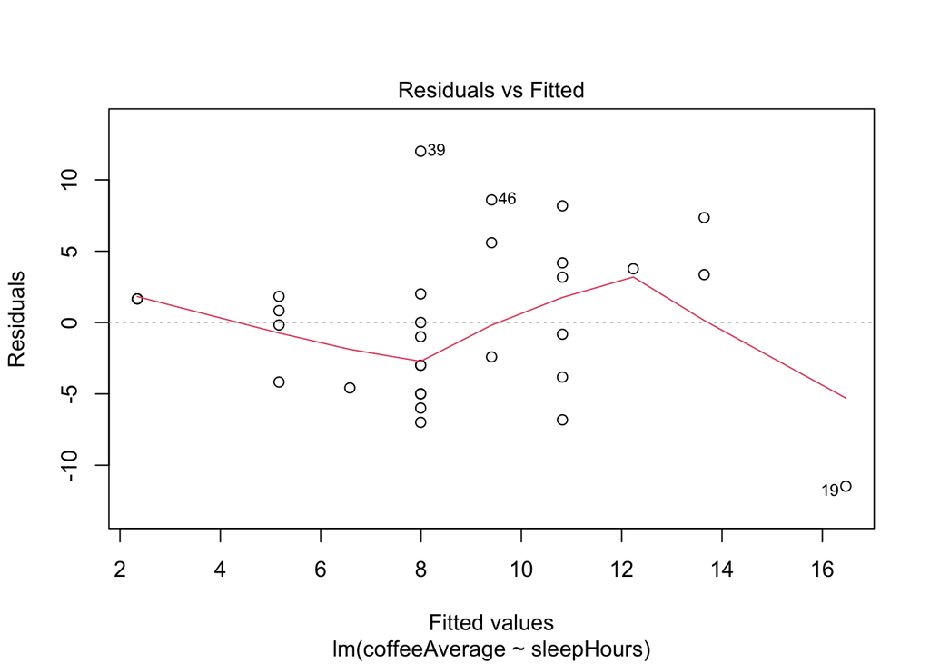

```r
### Resid vs Fitted
# we use plot() on the `fit` object
plot(fit, which = 1)
```

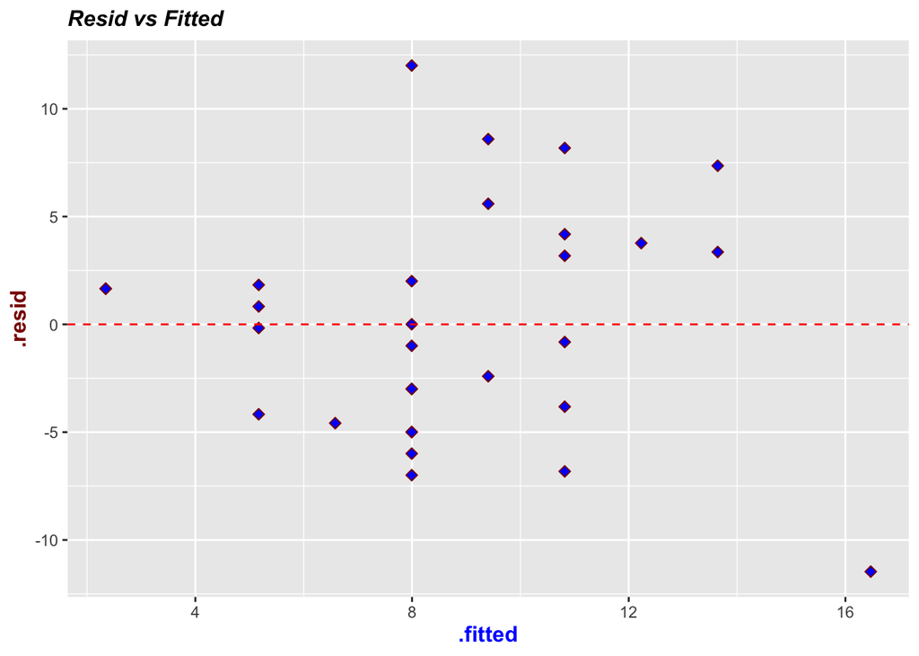

```r
### Resid vs Fitted - ggplot
ggplot(fit, aes(x = .fitted, y = .resid)) +
  geom_point(shape=23, fill="blue", color="darkred", size=2) +
  geom_hline(yintercept = 0, linetype = "dashed", colour = "red") +
  ggtitle("Resid vs Fitted") + theme(
plot.title = element_text(color="black", size=12, face="bold.italic" ),
axis.title.x = element_text(color="blue", size=12, face="bold"),
axis.title.y = element_text(color="darkred", size=12, face="bold")
)
```

Here is again the plot with the fitted model in it.

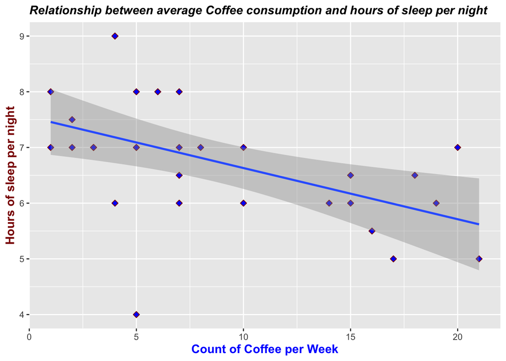

```r
### Integrated
ggplot(survey, aes(x = coffeeAverage, y = sleepHours)) +
  geom_point(shape=23, fill="blue", color="darkred", size=2) +
  geom_smooth(method = "lm") +  # *NEW* add linear regression model
  xlab("Count of Coffee per Week") +
  ylab("Hours of sleep per night") +
  ggtitle("Relationship between average Coffee consumption and hours of sleep per night") + theme(
plot.title = element_text(color="black", size=12, face="bold.italic" ),
axis.title.x = element_text(color="blue", size=12, face="bold"),
axis.title.y = element_text(color="darkred", size=12, face="bold")
)
```

Conclusion: In the next step we fit the model with these two variables. We can conclude that we have a p-value of 0.004034, which is relatively high, compared to the p-values we had in the tutorials. There appears to be a not very strong linear relationship between count of Coffee per Week and Hours of Sleep per night, indicated by the trend on the scatter plot, the correlation coefficient of -0.5094495 and the lightly random scatter of the residual plot. We can see a downtrend here and conclude, that the counts of coffee has a negative impact of the duration of sleep per night, probably due to the caffeine in it. The hours of sleep tend to go down, with increasing coffee (and caffeine) consumption.

### 2.2.2 Research Question 2

Secondly we ant to research the relation of coffee consumption and the quality of sleep an individual experiences.

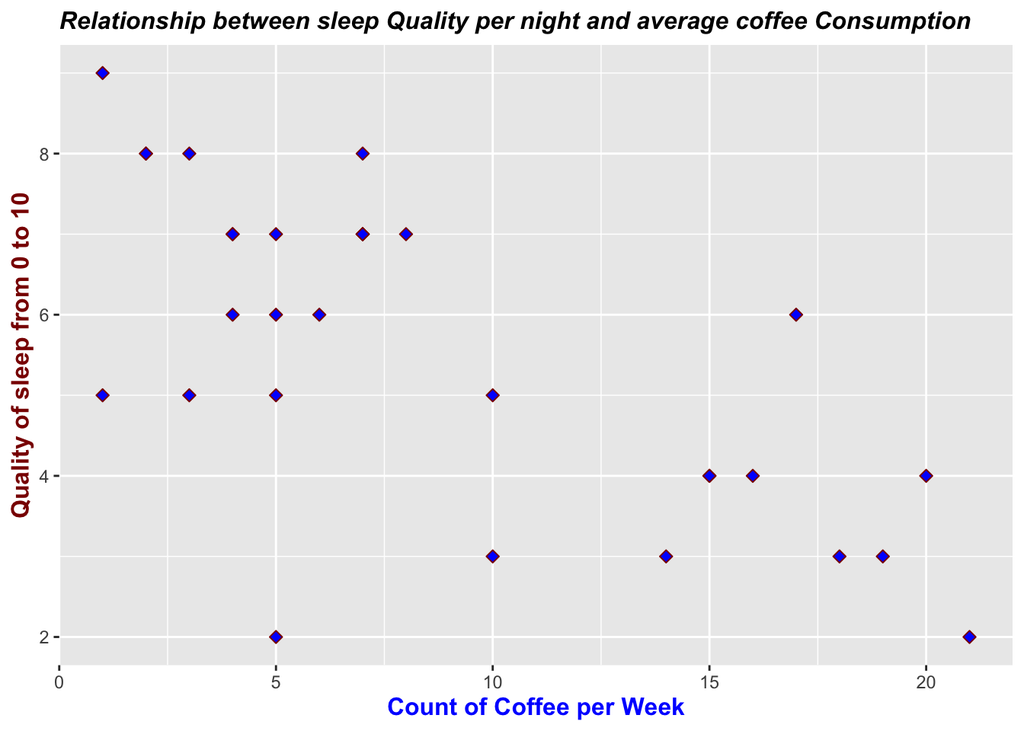

```r
# Quick look at top 5 rows of data
ggplot(survey, aes(x = coffeeAverage, y = sleepQuality)) +
  geom_point(shape=23, fill="blue", color="darkred", size=2) +                # then, generate a scatter plot layer, PLUS...
  # it would be a good idea to further improve the aesthetics of the plot
  xlab("Count of Coffee per Week") +
  ylab("Quality of sleep from 0 to 10") +
  ggtitle("Relationship between sleep Quality per night and average coffee Consumption") + theme(
plot.title = element_text(color="black", size=12, face="bold.italic" ),
axis.title.x = element_text(color="blue", size=12, face="bold"),
axis.title.y = element_text(color="darkred", size=12, face="bold")
)
```

We see a lower p-value of 3.229e-05 than in research question 1, which makes us more confident here.

```r
#Fit a model for Count of Coffee per Week to sleepQuality
fit <- lm(coffeeAverage~ sleepQuality, data = survey)
fit # print
```

```
##
## Call:
## lm(formula = coffeeAverage ~ sleepQuality, data = survey)
##
## Coefficients:
##  (Intercept)  sleepQuality
##       20.560        -2.143
```

```r
summary(fit)
```

```
##
## Call:
## lm(formula = coffeeAverage ~ sleepQuality, data = survey)
##
## Residuals:
##      Min       1Q   Median       3Q      Max
## -11.2732  -1.6639  -0.1998   3.0135   9.3002
##
## Coefficients:
##              Estimate Std. Error t value Pr(>|t|)
## (Intercept)   20.5599     2.5425   8.086 8.35e-09 ***
## sleepQuality  -2.1434     0.4335  -4.944 3.23e-05 ***
## ---
## Signif. codes:  0 '***' 0.001 '**' 0.01 '*' 0.05 '.' 0.1 ' ' 1
##
## Residual standard error: 4.618 on 28 degrees of freedom
## Multiple R-squared:  0.4661, Adjusted R-squared:  0.4471
## F-statistic: 24.45 on 1 and 28 DF,  p-value: 3.229e-05
```

We can see that the correlation here is higher in absolutes than with research question 1 with -0.682732.

```r
cor(survey$coffeeAverage, survey$sleepQuality) #
```

```
## [1] -0.682732
```

Now we do some testing, with resiaduals vs fitted.

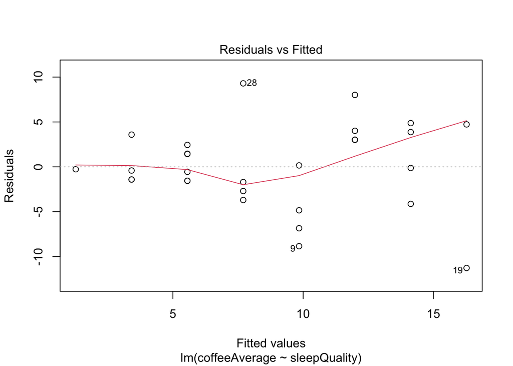

```r
# we use plot() on the `fit` object
plot(fit, which = 1)
```

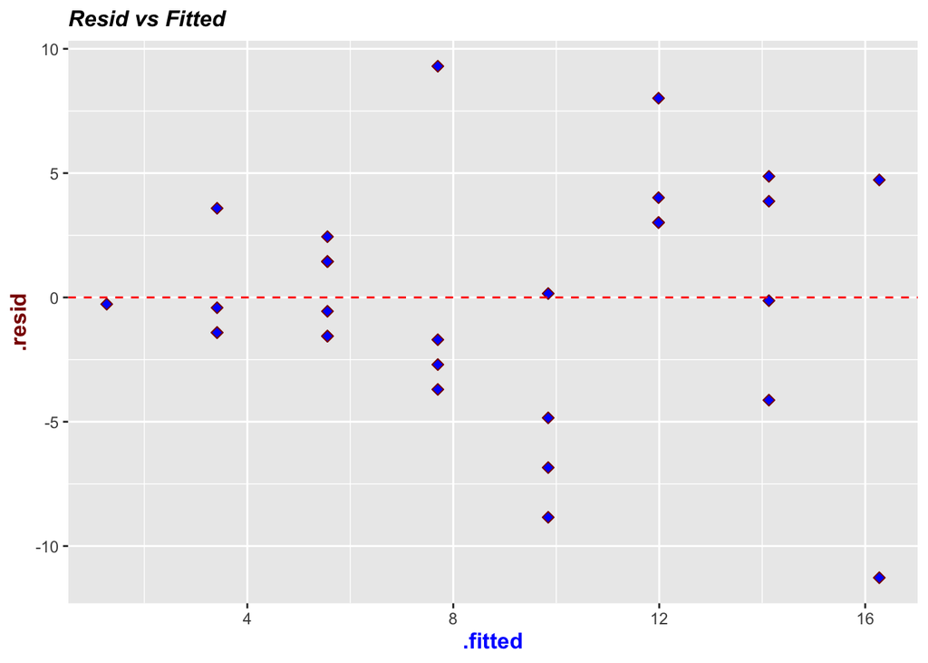

```r
ggplot(fit, aes(x = .fitted, y = .resid)) +
  geom_point(shape=23, fill="blue", color="darkred", size=2) +
  geom_hline(yintercept = 0, linetype = "dashed", colour = "red") +
  ggtitle("Resid vs Fitted") + theme(
plot.title = element_text(color="black", size=12, face="bold.italic" ),
axis.title.x = element_text(color="blue", size=12, face="bold"),
axis.title.y = element_text(color="darkred", size=12, face="bold")
)
```

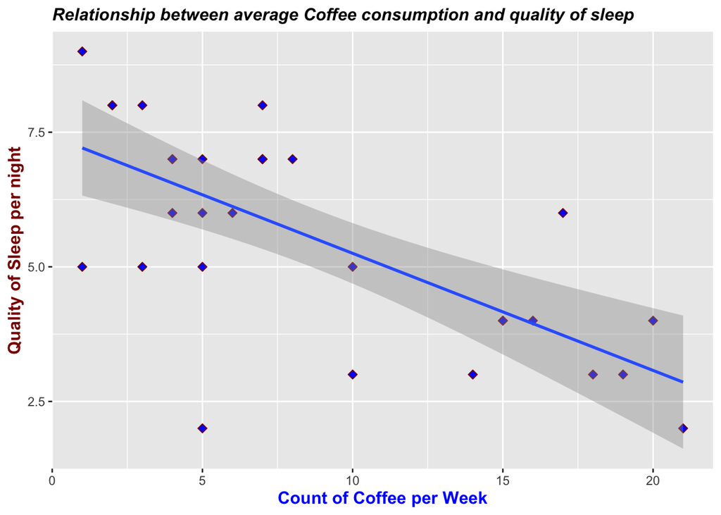

```r
ggplot(survey, aes(x = coffeeAverage, y = sleepQuality)) +
  geom_point(shape=23, fill="blue", color="darkred", size=2) +
  geom_smooth(method = "lm") +  # *NEW* add linear regression model
  xlab("Count of Coffee per Week") +
  ylab("Quality of Sleep per night") +
  ggtitle("Relationship between average Coffee consumption and quality of sleep") + theme(
plot.title = element_text(color="black", size=12, face="bold.italic" ),
axis.title.x = element_text(color="blue", size=12, face="bold"),
axis.title.y = element_text(color="darkred", size=12, face="bold")
)
```

There appears to be a lightly linear relationship between count of Coffee per Week and Quality of Sleep per night, indicated by the trend on the scatter plot, the correlation coefficient of -0.682732 and the random scatter of the residual plot. We can see a downtrend here and conclude, that the counts of coffee has a negative impact of the quality of sleep per night.

## 2.3 Articles

### 2.3.1 Article 1:

Adolescents reporting high caffeine intake were more likely to experience sleepiness in the morning.  
Referencing:  
Paraphrased: Clark (2017) states that high caffeine consumption amongst adolescents were 1.9 times more likely to experience complications in sleeping and were 1.8 times more likely to report tiredness in the morning as opposed to adolescents with a much less caffeine consumption  
Clark, I., & Landolt, H. P. (2017). Coffee, caffeine, and sleep: A systematic review of epidemiological studies and randomized controlled trials. Sleep Medicine Reviews, 31, 70–78. https://doi.org/10.1016/j.smrv.2016.01.006

### 2.3.2 Article 2:

According to Article 2 Poor sleep quality is associated with coffee and energy drink intake.  
Referencing:  
Sawa (2015) reports that in addition, the use of coffee and energy drinks, perceived stress, and excessive daytime sleepiness were linked to greater probabilities of having poor sleep quality.  
Sawah, M. A., Ruffin, N., Rimawi, M., Concerto, C., Aguglia, E., Chusid, E., Infortuna, C., & Battaglia, F. (2015). Perceived stress and coffee and energy drink consumption predict poor sleep quality in podiatric medical students. Journal of the American Podiatric Medical Association, 105(5), 429–434. https://doi.org/10.7547/14-082

### 2.3.3 Relation

The findings of Articles both relate to our findings, which say that students with higher coffee consumption experience worse sleep quality.